# ch03_01_01_movie_classification

## 영화 리뷰 데이터 분류하기

### 학습 내용

- 10000개의 단어로 이루어진 영화 리뷰 데이터를 활용하여 긍정, 부정을 예측하는 이진분류 신경망을 구현해 본다.
- 이를 위해 데이터 전처리에 대해 배워본다.

### 데이터 셋

- IMDB 데이터 셋
  - 총 5만개로 이루어진 긍정 부정의 리뷰
  - 이 데이터셋은 훈련 데이터 25,000개와 테스트 데이터 25,000개로 나뉘어 있고 각각 50%는 부정, 50%는 긍정 리뷰로 구성
  - 스탠포드 대학의 앤드류 마스(Andrew Maas)가 수집한 데이터 셋

### 1-1 데이터 준비

```python
from keras.datasets import imdb

(train_data, train_labels), (test_data, test_labels) = imdb.load_data(num_words=10000)
```

```
Downloading data from https://storage.googleapis.com/tensorflow/tf-keras-datasets/imdb.npz
```

```
<__array_function__ internals>:5: VisibleDeprecationWarning: Creating an ndarray from ragged nested sequences (which is a list-or-tuple of lists-or-tuples-or ndarrays with different lengths or shapes) is deprecated. If you meant to do this, you must specify 'dtype=object' when creating the ndarray
```

- 매개변수 num_words=10000은 훈련 데이터에서 가장 자주 나타나는 단어 10,000개만 사용하겠다는 의미. 드물게 나타나는 단어는 무시
- train_data와 test_data는 리뷰
- train_labels와 test_labels (긍정 : 1, 부정 : 0)

```python
print(train_data.shape, train_labels.shape)
print(test_data.shape, test_labels.shape)
```

```
(25000,) (25000,)
(25000,) (25000,)
```

- train_data는 여러개의 단어로 이루어진 리뷰. 리뷰 단어는 각각 매칭된 word index 값으로 이루어짐.
- train_labels는 1(긍정), 0(부정)이 됨.

```python
# train_data의 하나(numpy)에서 10개 정도 확인해 보기
print(type(train_data[0]),  len(train_data[0]))  # 자료형과 개수
train_data[0][0:10]
```

```
<class 'list'> 218
```

```
[1, 14, 22, 16, 43, 530, 973, 1622, 1385, 65]
```

```python
train_labels[0:5]
```

```
array([1, 0, 0, 1, 0], dtype=int64)
```

### 10개의 리뷰에 대한 단어 인덱스 최대값 확인

- 자주 등장하는 단어 10000개로 제한

```python
[max(sequence) for sequence in train_data][0:10] # 10개 리뷰의 각 리뷰의 단어 인덱스의 최대값
```

```
[7486, 9837, 6905, 9941, 7224, 7982, 9363, 9820, 7612, 8419]
```

```python
max([max(sequence) for sequence in train_data])
```

```
9999
```

### 리뷰 데이터 하나를 영어 단어로 변경해 보기

- imdb.get_word_index() : 단어와 인덱스를 단어:인덱스 형태로 반환해 주는 것

```python
# word_index는 단어와 정수 인덱스를 매핑한 딕셔너리입니다
word_index = imdb.get_word_index()

# 전체 단어:인덱스 쌍의 수
print( len(word_index) )  # 88584개
print( word_index )
```

[output not shown]

### 인덱스별 단어들

```python
# 정수 인덱스와 단어를 매핑하도록 뒤집습니다
reverse_word_index = dict([(value, key) for (key, value) in word_index.items()])
reverse_word_index
```

[output not shown]

[output cut: 986 more lines]

### 인덱스 2번 단어 얻기

```python
# reverse_word_index의 기능 확인
dir(reverse_word_index)[-11:]
```

```
['clear',
 'copy',
 'fromkeys',
 'get',
 'items',
 'keys',
 'pop',
 'popitem',
 'setdefault',
 'update',
 'values']
```

```python
# reverse_word_index.get(인덱스)  # 인덱스에 해당되는 단어가 출력
# reverse_word_index.get(인덱스, '?')  # 인덱스에 해당되는 단어가 출력되는데, 단어가 없으면 ? 출력
reverse_word_index.get(2, '?')
```

```
'and'
```

### 첫번째 리뷰에 대해 각 단어를 리스트화 시키기

```python
train_data[0]  # 첫번째 리뷰(숫자 인덱스)
```

```
[1,
 14,
 22,
 16,
 43,
 530,
 973,
 1622,
 1385,
 65,
 458,
 4468,
 66,
 3941,
 4,
 173,
 36,
 256,
 5,
 25,
 100,
 43,
 838,
 112,
 50,
 670,
 2,
 9,
 35,
 480,
 284,
 5,
 150,
 4,
 172,
 112,
 167,
 2,
 336,
 385,
```

[output cut: 163 more lines]

```
 12,
 16,
 283,
 5,
 16,
 4472,
 113,
 103,
 32,
 15,
 16,
 5345,
 19,
 178,
 32]
```

```python
# train_data[0] : 하나의 리뷰(3, 6, 2, 5, 10...) => 218단어 ...
# [reverse_word_index.get(i - 3, '?') for i in train_data[0]]
print(len( train_data[0]) )  # 첫번째 리뷰는 218개 인덱스(단어)로 이루어져 있다.
print([i for i in train_data[0]])  # train_data[0]인덱스가 for문이 돌아가면서 리스트 형태로 만들어진다.
```

```
218
[1, 14, 22, 16, 43, 530, 973, 1622, 1385, 65, 458, 4468, 66, 3941, 4, 173, 36, 256, 5, 25, 100, 43, 838, 112, 50, 670, 2, 9, 35, 480, 284, 5, 150, 4, 172, 112, 167, 2, 336, 385, 39, 4, 172, 4536, 1111, 17, 546, 38, 13, 447, 4, 192, 50, 16, 6, 147, 2025, 19, 14, 22, 4, 1920, 4613, 469, 4, 22, 71, 87,…
```

```python
# 두번째 리뷰 - 189개 인덱스(단어)로 이루어져 있고, 이에 대한 리스트를 만들어 출력해 본다.
print(len( train_data[1] ))  # 첫번째 리뷰는 218개 인덱스(단어)로 이루어져 있다.
print([i for i in train_data[1] ])  # train_data[0]인덱스가 for문이 돌아가면서 리스트 형태로 만들어진다.
```

```
189
[1, 194, 1153, 194, 8255, 78, 228, 5, 6, 1463, 4369, 5012, 134, 26, 4, 715, 8, 118, 1634, 14, 394, 20, 13, 119, 954, 189, 102, 5, 207, 110, 3103, 21, 14, 69, 188, 8, 30, 23, 7, 4, 249, 126, 93, 4, 114, 9, 2300, 1523, 5, 647, 4, 116, 9, 35, 8163, 4, 229, 9, 340, 1322, 4, 118, 9, 4, 130, 4901, 19, 4, …
```

```python
# [reverse_word_index.get(i - 3, '?') for i in train_data[0]]
# 의미 : 각각의 인덱스(218)에 대한 단어를 리스트 형태로 만든다.
print("첫번째 리뷰의 인덱스를 단어로 매칭시켜서 보여준 것")
print([reverse_word_index.get(i - 3, '?') for i in train_data[0]])

# ' '.join([reverse_word_index.get(i - 3, '?') for i in train_data[0]])
# 각각의 단어 리스트를 공백하나를 넣어주면서 하나의 문자열로 묶어 준것.
```

```
첫번째 리뷰의 인덱스를 단어로 매칭시켜서 보여준 것
['?', 'this', 'film', 'was', 'just', 'brilliant', 'casting', 'location', 'scenery', 'story', 'direction', "everyone's", 'really', 'suited', 'the', 'part', 'they', 'played', 'and', 'you', 'could', 'just', 'imagine', 'being', 'there', 'robert', '?', 'is', 'an', 'amazing', 'actor', 'and', 'now', 'the',…
```

- 0, 1, 2는 '패딩', '문서 시작', '사전에 없음'을 위한 인덱스이므로 3을 빼준다.
- 첫번째 리뷰를 하나씩 인덱스를 확인 후, 매칭되는 단어를 추가. 없으면 '?'을 표시

```python
# 리뷰를 디코딩합니다.
# 0, 1, 2는 '패딩', '문서 시작', '사전에 없음'을 위한 인덱스이므로 3을 뺍니다
decoded_review = ' '.join([reverse_word_index.get(i - 3, '?') for i in train_data[0]])
decoded_review
```

```
"? this film was just brilliant casting location scenery story direction everyone's really suited the part they played and you could just imagine being there robert ? is an amazing actor and now the same being director ? father came from the same scottish island as myself so i loved the fact there w…
```

### 해보기

- 5번째 단어에 대해서 인덱스를 영문으로 바꿔서 표현해 보기

### 모델에 사용하기 위해 전처리-벡터화

### 리뷰 데이터는 다음과 같이 표현되었다.

- 원핫 인코딩
  - 전체 10개 단어
  - I, an, like, apple, korea, a, list, orange, pig, cat
  - 3 4 5 6 7 8 9 10 11 12
  - 0 0 0 0 0 0 0 0 0 0
- 나의 첫번째 리뷰
  - I like an apple -> (3, 5, 4, 6)
  - 0 0 0 0 0 0 0 0 0 0
  - 1 1 1 1 0 0 0 0 0 0
- 나의 두번째 리뷰
  - I like an orange -> (3, 5, 4, 10)
  - 1 1 1 0 0 0 0 1 0 0
- 나의 세번째 리뷰
  - my orange is pig -> (32000, 10, 50000, 11)
  - 0 0 0 0 0 0 0 1 1 0
- 또 다른 표현
  - 나의 첫번째 리뷰
  - I like an apple ->
  - 0 0 0 0 0 0 0 0 0 0
  - 1 1 1 1 0 0 0 0 0 0
  - (10, 0), (10, 1), (10, 2), (10,3)
- 나의 세번째 리뷰
  - my orange is pig ->
  - 0 0 0 0 0 0 0 0 0 0
  - 0 0 0 0 0 0 0 1 1 0
  - (10, 8), (10, 9)

### 1-2 데이터 준비

- 리스트를 원-핫 인코딩하여 0과 1의 벡터로 변환합니다.
- [3, 5]를 인덱스 3과 5의 위치는 1이고 그 외는 모두 0인 10,000차원의 벡터로 각각 변환

```python
import numpy as np

def vectorize_sequences(sequences, dimension=10000):
    # 크기가 (len(sequences), dimension))이고 모든 원소가 0인 행렬을 만듭니다
    results = np.zeros((len(sequences), dimension))

    for i, sequence in enumerate(sequences):
        results[i, sequence] = 1.  # results[i]에서 특정 인덱스의 위치를 1로 만듭니다
    return results
```

### 훈련 데이터를 벡터로 변환

- 1D (25000, )에서 -> 2D (25000, 10000)으로 변경

```python
print("변환 전 : ", train_data.shape)
X_train = vectorize_sequences(train_data)
print("변환 후 : ", X_train.shape)
X_train
```

```
변환 전 :  (25000,)
변환 후 :  (25000, 10000)
```

```
array([[0., 1., 1., ..., 0., 0., 0.],
       [0., 1., 1., ..., 0., 0., 0.],
       [0., 1., 1., ..., 0., 0., 0.],
       ...,
       [0., 1., 1., ..., 0., 0., 0.],
       [0., 1., 1., ..., 0., 0., 0.],
       [0., 1., 1., ..., 0., 0., 0.]])
```

### 테스트 데이터를 벡터로 변환

```python
print("변환 전 : ",test_data.shape)
X_test = vectorize_sequences(test_data)
print("변환 후 : ",X_test.shape)
X_test
```

```
변환 전 :  (25000,)
변환 후 :  (25000, 10000)
```

```
array([[0., 1., 1., ..., 0., 0., 0.],
       [0., 1., 1., ..., 0., 0., 0.],
       [0., 1., 1., ..., 0., 0., 0.],
       ...,
       [0., 1., 1., ..., 0., 0., 0.],
       [0., 1., 1., ..., 0., 0., 0.],
       [0., 1., 1., ..., 0., 0., 0.]])
```

### 레이블을 벡터로 바꾸기

- 리스트를 배열로 만들어준다.

```python
a = [1,2]
np.asarray(a)
```

```
array([1, 2])
```

```python
print(train_labels.shape)
print(test_labels.shape)
```

```
(25000,)
(25000,)
```

```python
y_train = np.asarray(train_labels).astype('float32')
y_test = np.asarray(test_labels).astype('float32')
```

```python
y_train
```

```
array([1., 0., 0., ..., 0., 1., 0.], dtype=float32)
```

```python
y_test
```

```
array([0., 1., 1., ..., 0., 0., 0.], dtype=float32)
```

### 1-3 신경망 모델 만들기

- 얼마나 많은 은닉층 사용할 것인가?
- 각 층에 얼마나 많은 은닉 유닛을 둘 것인가?

[figure not shown]

### 입력 데이터가 벡터(1D)이고 레이블은 스칼라(1 또는 0)입니다.

### 활성화 함수(Activation)이 필요한 이유

- 선형 층을 깊게 쌓아도 여전히 하나의 선형 연산이다. 층을 여러개로 구성하는 장점이 없다.
- 이를 풍부하게 만들어 층을 깊게 만드는 장점을 살리기 위해서는 비선형성 또는 활성화 함수를 추가해야한다.
- relu는 가장 인기있는 활성화 함수중의 하나이다.

```python
from keras import models
from keras import layers

model = models.Sequential()
model.add(layers.Dense(16, activation='relu', input_shape=(10000,)))
model.add(layers.Dense(16, activation='relu'))
model.add(layers.Dense(1, activation='sigmoid'))
```

### 손실함수와 optimizer(최적화 함수)를 선택

```python
model.compile(optimizer='rmsprop',
              loss='binary_crossentropy',
              metrics=['accuracy'])
```

### 옵티마이저의 매개변수를 설정해야 할 때,

```python
import tensorflow as tf
import keras
print(tf.__version__)
print(keras.__version__)
```

```
2.4.1
2.4.3
```

```python
from keras import optimizers

model.compile(optimizer=keras.optimizers.RMSprop(lr=0.01),
              loss='binary_crossentropy',
              metrics=['accuracy'])
```

### 다음과 같이 가능함.

```
from keras import losses
from keras import metrics

model.compile(optimizer=optimizers.RMSprop(lr=0.001),
              loss=losses.binary_crossentropy,
              metrics=[metrics.binary_accuracy])
```

### 훈련 데이터 검증

- 훈련하는 동안 처음 본 데이터에 대한 모델의 정확도를 측정하기 위해 원본 훈련 데이터에서 10,000의 샘플을 떼어서 검증 세트를 만들기

```python
X_train.shape, y_train.shape
```

```
((25000, 10000), (25000,))
```

- 처음 10000개까지를 검증용, 이후의 15000개를 학습용으로 이용

```python
X_val = X_train[:10000]
partial_X_train = X_train[10000:]

y_val = y_train[:10000]
partial_y_train = y_train[10000:]
```

```python
history = model.fit(partial_X_train,
                    partial_y_train,
                    epochs=20,
                    batch_size=512,
                    validation_data=(X_val, y_val))
```

```python
history_dict = history.history
history_dict.keys()
```

```
dict_keys(['loss', 'accuracy', 'val_loss', 'val_accuracy'])
```

```python
import matplotlib.pyplot as plt
```

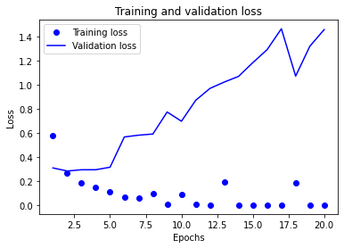

```python
acc = history.history['accuracy']
val_acc = history.history['val_accuracy']
loss = history.history['loss']
val_loss = history.history['val_loss']

epochs = range(1, len(acc) + 1)

# ‘bo’는 파란색 점을 의미합니다
plt.plot(epochs, loss, 'bo', label='Training loss')
# ‘b’는 파란색 실선을 의미합니다
plt.plot(epochs, val_loss, 'b', label='Validation loss')
plt.title('Training and validation loss')
plt.xlabel('Epochs')
plt.ylabel('Loss')
plt.legend()

plt.show()
```

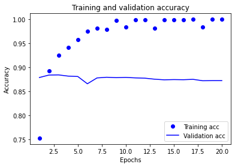

```python
plt.clf()   # 그래프를 초기화합니다
acc = history_dict['accuracy']
val_acc = history_dict['val_accuracy']

plt.plot(epochs, acc, 'bo', label='Training acc')
plt.plot(epochs, val_acc, 'b', label='Validation acc')
plt.title('Training and validation accuracy')
plt.xlabel('Epochs')
plt.ylabel('Accuracy')
plt.legend()

plt.show()
```

### 실습

- 신경망을 약간 변경한 후, 4에포크 돌리고 훈련시켜보기

### 처음부터 다시 새로운 신경망을 4번의 에포크 동안만 훈련하고 테스트 데이터에서 평가

- 모델을 훈련시킨 후에 이를 실전 환경에서 사용하고 싶다. predict메서드를 사용해서 어떤 리뷰가 긍정일 확률을 예측할 수 있다.

```python
model = models.Sequential()
model.add(layers.Dense(16, activation='relu', input_shape=(10000,)))
model.add(layers.Dense(16, activation='relu'))
model.add(layers.Dense(1, activation='sigmoid'))

model.compile(optimizer='rmsprop',
              loss='binary_crossentropy',
              metrics=['accuracy'])

model.fit(X_train, y_train, epochs=4, batch_size=512)
results = model.evaluate(X_test, y_test)
```

```python
results
```

```
[0.2995520234107971, 0.882319986820221]
```

### 1-4 예측 수행

```python
model.predict(X_test)
```

```
array([[0.15369171],
       [0.9999317 ],
       [0.72289145],
       ...,
       [0.1301493 ],
       [0.0598473 ],
       [0.50331956]], dtype=float32)
```

### 추가 해보기

- 1개 또는 3개의 은닉층을 사용하여 검증과 테스트 정확도 확인해 보기
- 층에 은닉 유닛을 줄이거나 늘려보기 32개, 64개 등
- binary_crossentropy대신에 mse 손실함수 사용.
- relu대신에 tanh 활성화 함수를 사용하기

### 추가 실습

- 01 3개의 은닉층 사용하기(노드수 동일)
- 02 2개의 은닉층 사용하기(노드수 동일)
- 03 은닉층 개수는 동일하게 하고 노드수 늘리기(32개)
- 04 은닉층 개수는 동일하게 하고 노드수 늘리기(64개)
- 05 은닉층 개수는 동일하게 하고 노드수 늘리기(128개)
- 06 tanh활성화 함수 사용하기
- 07 배치 사이즈 변경(512->128)
- 학습을 시킨이후에 그래프를 보고,
- 적절한 에폭수를 여러분이 지정하고,
- 최종결과 올리기

### 07 배치 사이즈 변경(512->128)

```python
model = models.Sequential()
model.add(layers.Dense(16, activation='relu', input_shape=(10000,)))
model.add(layers.Dense(16, activation='relu'))
model.add(layers.Dense(1, activation='sigmoid'))

model.compile(optimizer=keras.optimizers.RMSprop(lr=0.001),
              loss='binary_crossentropy',
              metrics=['accuracy'])

history = model.fit(partial_X_train,
                    partial_y_train,
                    epochs=20,
                    batch_size=128,
                    validation_data=(X_val, y_val))
```

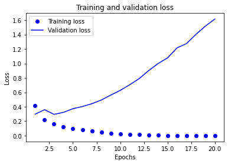

```python
import matplotlib.pyplot as plt

acc = history.history['accuracy']
val_acc = history.history['val_accuracy']
loss = history.history['loss']
val_loss = history.history['val_loss']

epochs = range(1, len(acc) + 1)

# ‘bo’는 파란색 점을 의미합니다
plt.plot(epochs, loss, 'bo', label='Training loss')
# ‘b’는 파란색 실선을 의미합니다
plt.plot(epochs, val_loss, 'b', label='Validation loss')
plt.title('Training and validation loss')
plt.xlabel('Epochs')
plt.ylabel('Loss')
plt.legend()

plt.show()
```

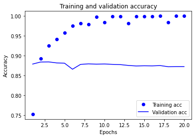

```python
plt.clf()   # 그래프를 초기화합니다
acc = history_dict['accuracy']
val_acc = history_dict['val_accuracy']

plt.plot(epochs, acc, 'bo', label='Training acc')
plt.plot(epochs, val_acc, 'b', label='Validation acc')
plt.title('Training and validation accuracy')
plt.xlabel('Epochs')
plt.ylabel('Accuracy')
plt.legend()

plt.show()
```

```python
model = models.Sequential()
model.add(layers.Dense(16, activation='relu', input_shape=(10000,)))
model.add(layers.Dense(16, activation='relu'))
model.add(layers.Dense(1, activation='sigmoid'))

model.compile(optimizer=keras.optimizers.RMSprop(lr=0.001),
              loss='binary_crossentropy',
              metrics=['accuracy'])

model.fit(X_train, y_train, epochs=4, batch_size=128)
results = model.evaluate(X_test, y_test)
print("에폭수 : ", epochs, "배치사이즈 :", 128)
print("loss , accuracy", results)
```

```
에폭수 :  range(1, 21) 배치사이즈 : 128
loss , accuracy [0.367267370223999, 0.8672000169754028]
```

### 정리해보기

- 원본 데이터를 신경망에 주입하기 위해서 꽤 많은 전처리가 필요.
- 이진 분류의 문제에서 네트워크는 하나의 유닛과 sigmoid 활성화 함수를 가진 Dense층으로 끝나야 함.
  - 이 신경망의 출력은 확률을 나타내는 0과 1 사이의 스칼라 값이다.
  - 이진 분류 문제에서 이런 스칼라 시그모이드 출력에 대해 사용할 손실함수는 binary_crossentropy
- 훈련 데이터에 대해 성능이 향상됨에 따라 신경망은 과대적합이 시작된다. 따라서 훈련 세트 이외의 데이터에서 성능 모니터링을 해야 함.